# UIS Drug Treatment Study

Lallen Johnson

2024-01-08

The [UIS Drug Treatment Study](https://vincentarelbundock.github.io/Rdatasets/doc/quantreg/uis.html) randomly assigned 628 persons addicted to drugs to shorter (control) or longer (intervention) treatment programs. Complete data are available for 575 observations. We want to know if the time to relapse is significantly different for those two groups.

```r
uis <- read.csv('https://vincentarelbundock.github.io/Rdatasets/csv/quantreg/uis.csv')
ls(uis) #lists variables in your dataframe
```

```
##  [1] "AGE"      "BECK"     "CENSOR"   "FRAC"     "HC"       "ID"
##  [7] "IV"       "IV3"      "LEN.T"    "LNDT"     "ND1"      "ND2"
## [13] "NDT"      "RACE"     "rownames" "SITE"     "TIME"     "TREAT"
## [19] "Y"
```

The average time to relapse for all participants was about 242 days.

```r
mean(uis$TIME)
```

```
## [1] 241.5652
```

## Plot overall distribution of relapse time

The overall time to relapse distribution is bimodal. Relapse peaks about 100 days after treatment completion and again about 500 days after completion.

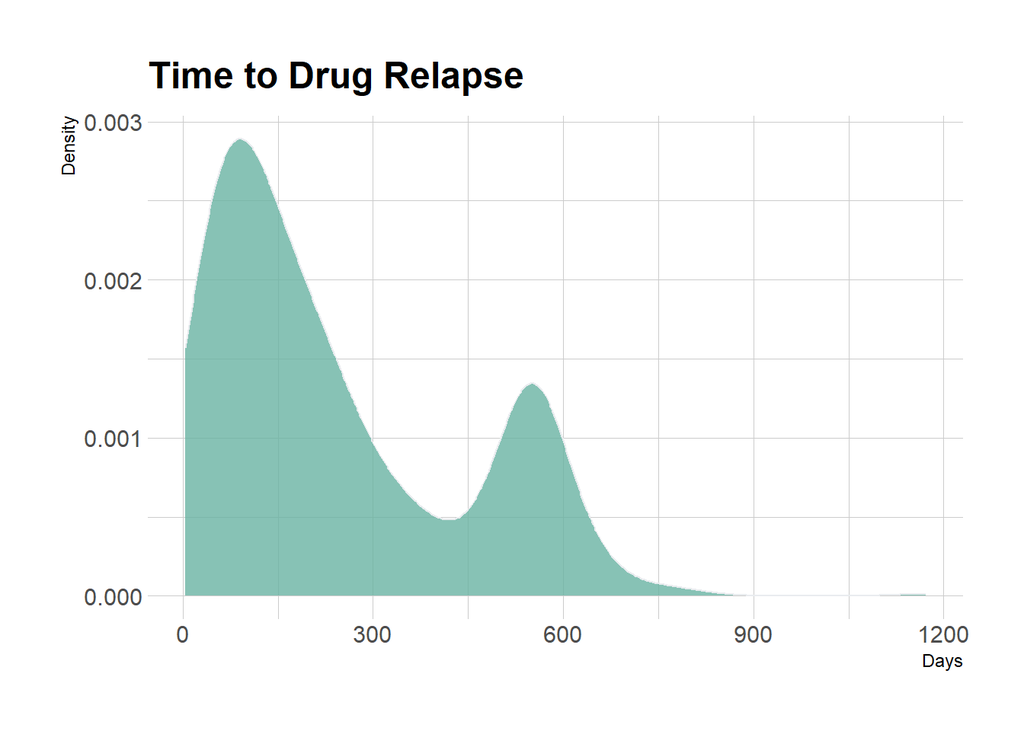

```r
library(ggplot2)
library(hrbrthemes)
relapseplot <- ggplot(uis, aes(x=TIME)) + geom_density(fill="#69b3a2", color="#e9ecef", alpha=0.8) + ggtitle("Time to Drug Relapse") + labs(x="Days", y="Density")+ theme_ipsum()
relapseplot
```

## Distribution of relapse time by treatment and control group

The general distribution for relapse time is similar across those who received short and long drug treatment. But those who received long treatment were less likely than the short treatment group to relapse around 100 days post-release. Instead, they are slightly *more* likely than the short treatment group to relapse about 500 days after treatment completion.

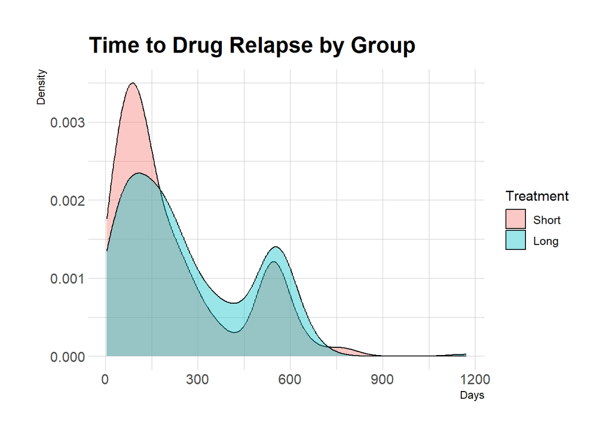

```r
uis$TREAT1 <- factor(uis$TREAT, levels=c(0,1), labels = c('Short', 'Long')) #gotta tell R that TREAT is a factor variable
relapseplot1 <- ggplot(uis, aes(x=TIME, fill = TREAT1)) + geom_density(alpha=.4) + labs(title="Time to Drug Relapse by Group", x = "Days", y = "Density", fill = "Treatment") + theme_ipsum()
relapseplot1
```

## t-tests

### Base R

```r
t.test(TIME ~ TREAT, data = uis)
```

```
##
##  Welch Two Sample t-test
##
## data:  TIME by TREAT
## t = -2.8478, df = 570.85, p-value = 0.00456
## alternative hypothesis: true difference in means between group 0 and group 1 is not equal to 0
## 95 percent confidence interval:
##  -79.86566 -14.66697
## sample estimates:
## mean in group 0 mean in group 1
##        218.0554        265.3217
```

### Tidyverse

```r
library(tidyverse)
uis %>%
  select(TREAT, TIME) %>%
  filter(TREAT %in% c(0,1)) %>%
  t.test(TIME ~ TREAT, data = .)
```

```
##
##  Welch Two Sample t-test
##
## data:  TIME by TREAT
## t = -2.8478, df = 570.85, p-value = 0.00456
## alternative hypothesis: true difference in means between group 0 and group 1 is not equal to 0
## 95 percent confidence interval:
##  -79.86566 -14.66697
## sample estimates:
## mean in group 0 mean in group 1
##        218.0554        265.3217
```